# Risk Factor Analysis

## Outcome Variable

**Outcome Variable:** sstunted

## Predictor Variables

**Intervention Variable:** mage

**Adjustment Set:**

- arm
- meducyrs
- feducyrs
- W_mhtcm
- single
- delta_meducyrs
- delta_feducyrs
- delta_W_mhtcm
- delta_single

## Stratifying Variables

The analysis was stratified on these variable(s):

- agecat
- studyid
- country

## Data Summary

| agecat | studyid | country | mage | sstunted | n_cell | n |
| --- | --- | --- | --- | --- | --- | --- |
| Birth | ki0047075b-MAL-ED | BANGLADESH | [20-30) | 0 | 170 | 257 |
| Birth | ki0047075b-MAL-ED | BANGLADESH | [20-30) | 1 | 6 | 257 |
| Birth | ki0047075b-MAL-ED | BANGLADESH | <20 | 0 | 35 | 257 |
| Birth | ki0047075b-MAL-ED | BANGLADESH | <20 | 1 | 1 | 257 |
| Birth | ki0047075b-MAL-ED | BANGLADESH | >=30 | 0 | 43 | 257 |
| Birth | ki0047075b-MAL-ED | BANGLADESH | >=30 | 1 | 2 | 257 |
| Birth | ki0047075b-MAL-ED | BRAZIL | [20-30) | 0 | 111 | 191 |
| Birth | ki0047075b-MAL-ED | BRAZIL | [20-30) | 1 | 6 | 191 |
| Birth | ki0047075b-MAL-ED | BRAZIL | <20 | 0 | 33 | 191 |
| Birth | ki0047075b-MAL-ED | BRAZIL | <20 | 1 | 1 | 191 |
| Birth | ki0047075b-MAL-ED | BRAZIL | >=30 | 0 | 39 | 191 |
| Birth | ki0047075b-MAL-ED | BRAZIL | >=30 | 1 | 1 | 191 |
| Birth | ki0047075b-MAL-ED | INDIA | [20-30) | 0 | 159 | 205 |
| Birth | ki0047075b-MAL-ED | INDIA | [20-30) | 1 | 6 | 205 |
| Birth | ki0047075b-MAL-ED | INDIA | <20 | 0 | 24 | 205 |
| Birth | ki0047075b-MAL-ED | INDIA | <20 | 1 | 1 | 205 |
| Birth | ki0047075b-MAL-ED | INDIA | >=30 | 0 | 15 | 205 |
| Birth | ki0047075b-MAL-ED | INDIA | >=30 | 1 | 0 | 205 |
| Birth | ki0047075b-MAL-ED | NEPAL | [20-30) | 0 | 128 | 173 |
| Birth | ki0047075b-MAL-ED | NEPAL | [20-30) | 1 | 4 | 173 |
| Birth | ki0047075b-MAL-ED | NEPAL | <20 | 0 | 4 | 173 |
| Birth | ki0047075b-MAL-ED | NEPAL | <20 | 1 | 1 | 173 |
| Birth | ki0047075b-MAL-ED | NEPAL | >=30 | 0 | 35 | 173 |
| Birth | ki0047075b-MAL-ED | NEPAL | >=30 | 1 | 1 | 173 |
| Birth | ki0047075b-MAL-ED | PERU | [20-30) | 0 | 142 | 287 |
| Birth | ki0047075b-MAL-ED | PERU | [20-30) | 1 | 3 | 287 |
| Birth | ki0047075b-MAL-ED | PERU | <20 | 0 | 73 | 287 |
| Birth | ki0047075b-MAL-ED | PERU | <20 | 1 | 4 | 287 |
| Birth | ki0047075b-MAL-ED | PERU | >=30 | 0 | 64 | 287 |
| Birth | ki0047075b-MAL-ED | PERU | >=30 | 1 | 1 | 287 |

[output cut: 378 more lines]

The following strata were considered:

- agecat: 24 months, studyid: ki0047075b-MAL-ED, country: BANGLADESH
- agecat: 24 months, studyid: ki0047075b-MAL-ED, country: BRAZIL
- agecat: 24 months, studyid: ki0047075b-MAL-ED, country: INDIA
- agecat: 24 months, studyid: ki0047075b-MAL-ED, country: NEPAL
- agecat: 24 months, studyid: ki0047075b-MAL-ED, country: PERU
- agecat: 24 months, studyid: ki0047075b-MAL-ED, country: SOUTH AFRICA
- agecat: 24 months, studyid: ki0047075b-MAL-ED, country: TANZANIA, UNITED REPUBLIC OF
- agecat: 24 months, studyid: ki1000108-CMC-V-BCS-2002, country: INDIA
- agecat: 24 months, studyid: ki1000108-IRC, country: INDIA
- agecat: 24 months, studyid: ki1017093-NIH-Birth, country: BANGLADESH
- agecat: 24 months, studyid: ki1017093b-PROVIDE, country: BANGLADESH
- agecat: 24 months, studyid: ki1017093c-NIH-Crypto, country: BANGLADESH
- agecat: 24 months, studyid: ki1066203-TanzaniaChild2, country: TANZANIA, UNITED REPUBLIC OF
- agecat: 24 months, studyid: ki1101329-Keneba, country: GAMBIA
- agecat: 24 months, studyid: ki1113344-GMS-Nepal, country: NEPAL
- agecat: 24 months, studyid: ki1119695-PROBIT, country: BELARUS
- agecat: 24 months, studyid: ki1126311-ZVITAMBO, country: ZIMBABWE
- agecat: 24 months, studyid: ki1135781-COHORTS, country: GUATEMALA
- agecat: 24 months, studyid: ki1135781-COHORTS, country: INDIA
- agecat: 24 months, studyid: ki1135781-COHORTS, country: PHILIPPINES
- agecat: 24 months, studyid: ki1148112-LCNI-5, country: MALAWI
- agecat: 24 months, studyid: kiGH5241-JiVitA-3, country: BANGLADESH
- agecat: 6 months, studyid: ki0047075b-MAL-ED, country: BANGLADESH
- agecat: 6 months, studyid: ki0047075b-MAL-ED, country: BRAZIL
- agecat: 6 months, studyid: ki0047075b-MAL-ED, country: INDIA
- agecat: 6 months, studyid: ki0047075b-MAL-ED, country: NEPAL
- agecat: 6 months, studyid: ki0047075b-MAL-ED, country: PERU
- agecat: 6 months, studyid: ki0047075b-MAL-ED, country: SOUTH AFRICA
- agecat: 6 months, studyid: ki0047075b-MAL-ED, country: TANZANIA, UNITED REPUBLIC OF
- agecat: 6 months, studyid: ki1000108-CMC-V-BCS-2002, country: INDIA
- agecat: 6 months, studyid: ki1000108-IRC, country: INDIA
- agecat: 6 months, studyid: ki1000109-EE, country: PAKISTAN
- agecat: 6 months, studyid: ki1000304b-SAS-CompFeed, country: INDIA
- agecat: 6 months, studyid: ki1000304b-SAS-FoodSuppl, country: INDIA
- agecat: 6 months, studyid: ki1017093-NIH-Birth, country: BANGLADESH
- agecat: 6 months, studyid: ki1017093b-PROVIDE, country: BANGLADESH
- agecat: 6 months, studyid: ki1017093c-NIH-Crypto, country: BANGLADESH
- agecat: 6 months, studyid: ki1066203-TanzaniaChild2, country: TANZANIA, UNITED REPUBLIC OF
- agecat: 6 months, studyid: ki1101329-Keneba, country: GAMBIA
- agecat: 6 months, studyid: ki1112895-Guatemala BSC, country: GUATEMALA
- agecat: 6 months, studyid: ki1113344-GMS-Nepal, country: NEPAL
- agecat: 6 months, studyid: ki1119695-PROBIT, country: BELARUS
- agecat: 6 months, studyid: ki1126311-ZVITAMBO, country: ZIMBABWE
- agecat: 6 months, studyid: ki1135781-COHORTS, country: GUATEMALA
- agecat: 6 months, studyid: ki1135781-COHORTS, country: INDIA
- agecat: 6 months, studyid: ki1135781-COHORTS, country: PHILIPPINES
- agecat: 6 months, studyid: ki1148112-LCNI-5, country: MALAWI
- agecat: 6 months, studyid: kiGH5241-JiVitA-3, country: BANGLADESH
- agecat: Birth, studyid: ki0047075b-MAL-ED, country: BANGLADESH
- agecat: Birth, studyid: ki0047075b-MAL-ED, country: BRAZIL
- agecat: Birth, studyid: ki0047075b-MAL-ED, country: INDIA
- agecat: Birth, studyid: ki0047075b-MAL-ED, country: NEPAL
- agecat: Birth, studyid: ki0047075b-MAL-ED, country: PERU
- agecat: Birth, studyid: ki0047075b-MAL-ED, country: SOUTH AFRICA
- agecat: Birth, studyid: ki0047075b-MAL-ED, country: TANZANIA, UNITED REPUBLIC OF
- agecat: Birth, studyid: ki1000108-CMC-V-BCS-2002, country: INDIA
- agecat: Birth, studyid: ki1000108-IRC, country: INDIA
- agecat: Birth, studyid: ki1000109-EE, country: PAKISTAN
- agecat: Birth, studyid: ki1000304b-SAS-CompFeed, country: INDIA
- agecat: Birth, studyid: ki1017093-NIH-Birth, country: BANGLADESH
- agecat: Birth, studyid: ki1017093c-NIH-Crypto, country: BANGLADESH
- agecat: Birth, studyid: ki1101329-Keneba, country: GAMBIA
- agecat: Birth, studyid: ki1119695-PROBIT, country: BELARUS
- agecat: Birth, studyid: ki1126311-ZVITAMBO, country: ZIMBABWE
- agecat: Birth, studyid: ki1135781-COHORTS, country: GUATEMALA
- agecat: Birth, studyid: ki1135781-COHORTS, country: INDIA
- agecat: Birth, studyid: ki1135781-COHORTS, country: PHILIPPINES
- agecat: Birth, studyid: kiGH5241-JiVitA-3, country: BANGLADESH

### Dropped Strata

Some strata were dropped due to rare outcomes:

- agecat: Birth, studyid: ki0047075b-MAL-ED, country: BANGLADESH
- agecat: Birth, studyid: ki0047075b-MAL-ED, country: BRAZIL
- agecat: Birth, studyid: ki0047075b-MAL-ED, country: INDIA
- agecat: Birth, studyid: ki0047075b-MAL-ED, country: NEPAL
- agecat: Birth, studyid: ki0047075b-MAL-ED, country: PERU
- agecat: Birth, studyid: ki0047075b-MAL-ED, country: SOUTH AFRICA
- agecat: Birth, studyid: ki0047075b-MAL-ED, country: TANZANIA, UNITED REPUBLIC OF
- agecat: Birth, studyid: ki1000108-CMC-V-BCS-2002, country: INDIA
- agecat: Birth, studyid: ki1000108-IRC, country: INDIA
- agecat: Birth, studyid: ki1000109-EE, country: PAKISTAN
- agecat: Birth, studyid: ki1000304b-SAS-CompFeed, country: INDIA
- agecat: Birth, studyid: ki1017093-NIH-Birth, country: BANGLADESH
- agecat: Birth, studyid: ki1017093c-NIH-Crypto, country: BANGLADESH
- agecat: Birth, studyid: ki1119695-PROBIT, country: BELARUS
- agecat: Birth, studyid: ki1135781-COHORTS, country: GUATEMALA
- agecat: 6 months, studyid: ki0047075b-MAL-ED, country: BANGLADESH
- agecat: 6 months, studyid: ki0047075b-MAL-ED, country: BRAZIL
- agecat: 6 months, studyid: ki0047075b-MAL-ED, country: INDIA
- agecat: 6 months, studyid: ki0047075b-MAL-ED, country: NEPAL
- agecat: 6 months, studyid: ki0047075b-MAL-ED, country: PERU
- agecat: 6 months, studyid: ki0047075b-MAL-ED, country: SOUTH AFRICA
- agecat: 6 months, studyid: ki0047075b-MAL-ED, country: TANZANIA, UNITED REPUBLIC OF
- agecat: 6 months, studyid: ki1000108-CMC-V-BCS-2002, country: INDIA
- agecat: 6 months, studyid: ki1000108-IRC, country: INDIA
- agecat: 6 months, studyid: ki1000109-EE, country: PAKISTAN
- agecat: 6 months, studyid: ki1017093-NIH-Birth, country: BANGLADESH
- agecat: 6 months, studyid: ki1017093b-PROVIDE, country: BANGLADESH
- agecat: 6 months, studyid: ki1066203-TanzaniaChild2, country: TANZANIA, UNITED REPUBLIC OF
- agecat: 6 months, studyid: ki1101329-Keneba, country: GAMBIA
- agecat: 6 months, studyid: ki1112895-Guatemala BSC, country: GUATEMALA
- agecat: 6 months, studyid: ki1148112-LCNI-5, country: MALAWI
- agecat: 24 months, studyid: ki0047075b-MAL-ED, country: BRAZIL
- agecat: 24 months, studyid: ki0047075b-MAL-ED, country: INDIA
- agecat: 24 months, studyid: ki0047075b-MAL-ED, country: NEPAL
- agecat: 24 months, studyid: ki0047075b-MAL-ED, country: PERU
- agecat: 24 months, studyid: ki0047075b-MAL-ED, country: SOUTH AFRICA
- agecat: 24 months, studyid: ki0047075b-MAL-ED, country: TANZANIA, UNITED REPUBLIC OF
- agecat: 24 months, studyid: ki1000108-IRC, country: INDIA
- agecat: 24 months, studyid: ki1017093-NIH-Birth, country: BANGLADESH
- agecat: 24 months, studyid: ki1017093c-NIH-Crypto, country: BANGLADESH
- agecat: 24 months, studyid: ki1066203-TanzaniaChild2, country: TANZANIA, UNITED REPUBLIC OF

## Methods Detail

We’re interested in the causal parameters $E[Y_a]$ for all values of $a \in \mathcal{A}$. These parameters represent the mean outcome if, possibly contrary to fact, we intervened to set all units to have $A=a$. Under the randomization and positivity assumptions, these are identified by the statistical parameters $\psi_a=E_W[E_{Y|A,W}(Y|A=a,W)]$. In addition, we’re interested in the mean of $Y$, $E[Y]$ under no intervention (the observed mean). We will estimate these parameters by using SuperLearner to fit the relevant likelihood factors – $E_{Y|A,W}(Y|A=a,W)$ and $p(A=a|W)$, and then updating our likelihood fit using a joint TMLE.

For unadjusted analyses ($W=\{\}$), initial likelihoods were estimated using Lrnr_glm to estimate the simple $E(Y|A)$ and Lrnr_mean to estimate $p(A)$. For adjusted analyses, a small library containing Lrnr_glmnet, Lrnr_xgboost, and Lrnr_mean was used.

Having estimated these parameters, we will then use the delta method to estimate relative risks and attributable risks relative to a prespecified baseline level of $A$.

# Results Detail

## Results Plots

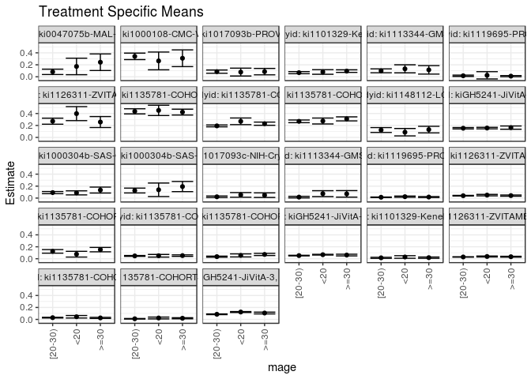

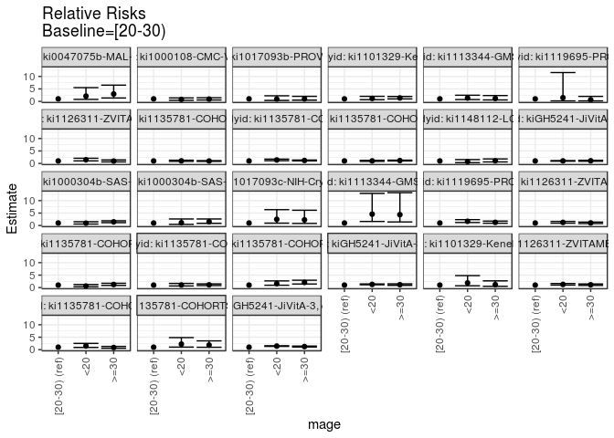

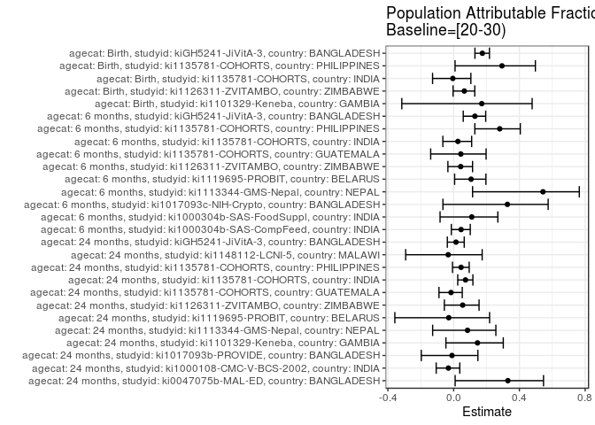

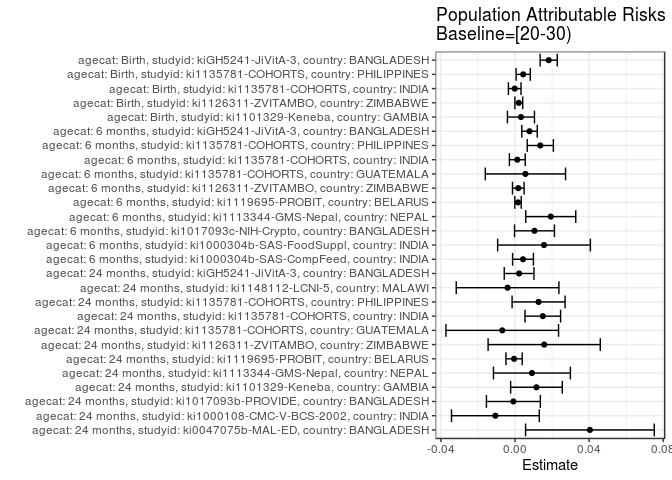

## Results Table

### Parameter: TSM

| agecat | studyid | country | intervention_level | baseline_level | estimate | ci_lower | ci_upper |
| --- | --- | --- | --- | --- | --- | --- | --- |
| Birth | ki1101329-Keneba | GAMBIA | [20-30) | NA | 0.0156028 | 0.0064516 | 0.0247541 |
| Birth | ki1101329-Keneba | GAMBIA | <20 | NA | 0.0294118 | 0.0079395 | 0.0508841 |
| Birth | ki1101329-Keneba | GAMBIA | >=30 | NA | 0.0183946 | 0.0076213 | 0.0291680 |
| Birth | ki1126311-ZVITAMBO | ZIMBABWE | [20-30) | NA | 0.0297673 | 0.0263079 | 0.0332266 |
| Birth | ki1126311-ZVITAMBO | ZIMBABWE | <20 | NA | 0.0378110 | 0.0296966 | 0.0459254 |
| Birth | ki1126311-ZVITAMBO | ZIMBABWE | >=30 | NA | 0.0336778 | 0.0262759 | 0.0410798 |
| Birth | ki1135781-COHORTS | INDIA | [20-30) | NA | 0.0294147 | 0.0234935 | 0.0353359 |
| Birth | ki1135781-COHORTS | INDIA | <20 | NA | 0.0443211 | 0.0235345 | 0.0651077 |
| Birth | ki1135781-COHORTS | INDIA | >=30 | NA | 0.0252652 | 0.0160864 | 0.0344439 |
| Birth | ki1135781-COHORTS | PHILIPPINES | [20-30) | NA | 0.0106479 | 0.0059227 | 0.0153732 |
| Birth | ki1135781-COHORTS | PHILIPPINES | <20 | NA | 0.0237099 | 0.0085749 | 0.0388449 |
| Birth | ki1135781-COHORTS | PHILIPPINES | >=30 | NA | 0.0196655 | 0.0104445 | 0.0288865 |
| Birth | kiGH5241-JiVitA-3 | BANGLADESH | [20-30) | NA | 0.0858691 | 0.0797085 | 0.0920298 |
| Birth | kiGH5241-JiVitA-3 | BANGLADESH | <20 | NA | 0.1237808 | 0.1161693 | 0.1313922 |
| Birth | kiGH5241-JiVitA-3 | BANGLADESH | >=30 | NA | 0.1068395 | 0.0919980 | 0.1216809 |
| 6 months | ki1000304b-SAS-CompFeed | INDIA | [20-30) | NA | 0.0914746 | 0.0734132 | 0.1095360 |
| 6 months | ki1000304b-SAS-CompFeed | INDIA | <20 | NA | 0.0873281 | 0.0533784 | 0.1212778 |
| 6 months | ki1000304b-SAS-CompFeed | INDIA | >=30 | NA | 0.1343611 | 0.0847621 | 0.1839602 |
| 6 months | ki1000304b-SAS-FoodSuppl | INDIA | [20-30) | NA | 0.1264368 | 0.0860644 | 0.1668091 |
| 6 months | ki1000304b-SAS-FoodSuppl | INDIA | <20 | NA | 0.1388889 | 0.0257707 | 0.2520071 |
| 6 months | ki1000304b-SAS-FoodSuppl | INDIA | >=30 | NA | 0.1927711 | 0.1077943 | 0.2777479 |
| 6 months | ki1017093c-NIH-Crypto | BANGLADESH | [20-30) | NA | 0.0216450 | 0.0083662 | 0.0349238 |
| 6 months | ki1017093c-NIH-Crypto | BANGLADESH | <20 | NA | 0.0534351 | 0.0148957 | 0.0919745 |
| 6 months | ki1017093c-NIH-Crypto | BANGLADESH | >=30 | NA | 0.0491803 | 0.0107816 | 0.0875791 |
| 6 months | ki1113344-GMS-Nepal | NEPAL | [20-30) | NA | 0.0162162 | 0.0033350 | 0.0290975 |
| 6 months | ki1113344-GMS-Nepal | NEPAL | <20 | NA | 0.0740741 | 0.0246381 | 0.1235101 |
| 6 months | ki1113344-GMS-Nepal | NEPAL | >=30 | NA | 0.0705882 | 0.0160884 | 0.1250880 |
| 6 months | ki1119695-PROBIT | BELARUS | [20-30) | NA | 0.0137811 | 0.0092185 | 0.0183437 |
| 6 months | ki1119695-PROBIT | BELARUS | <20 | NA | 0.0233409 | 0.0127219 | 0.0339599 |
| 6 months | ki1119695-PROBIT | BELARUS | >=30 | NA | 0.0174674 | 0.0088219 | 0.0261129 |

[output cut: 51 more lines]

### Parameter: E(Y)

| agecat | studyid | country | intervention_level | baseline_level | estimate | ci_lower | ci_upper |
| --- | --- | --- | --- | --- | --- | --- | --- |
| Birth | ki1101329-Keneba | GAMBIA | NA | NA | 0.0188189 | 0.0120322 | 0.0256057 |
| Birth | ki1126311-ZVITAMBO | ZIMBABWE | NA | NA | 0.0318347 | 0.0289044 | 0.0347649 |
| Birth | ki1135781-COHORTS | INDIA | NA | NA | 0.0292683 | 0.0244566 | 0.0340800 |
| Birth | ki1135781-COHORTS | PHILIPPINES | NA | NA | 0.0150820 | 0.0107558 | 0.0194081 |
| Birth | kiGH5241-JiVitA-3 | BANGLADESH | NA | NA | 0.1040657 | 0.0994001 | 0.1087313 |
| 6 months | ki1000304b-SAS-CompFeed | INDIA | NA | NA | 0.0958084 | 0.0774939 | 0.1141229 |
| 6 months | ki1000304b-SAS-FoodSuppl | INDIA | NA | NA | 0.1421053 | 0.1069532 | 0.1772573 |
| 6 months | ki1017093c-NIH-Crypto | BANGLADESH | NA | NA | 0.0321678 | 0.0192256 | 0.0451101 |
| 6 months | ki1113344-GMS-Nepal | NEPAL | NA | NA | 0.0355240 | 0.0202206 | 0.0508273 |
| 6 months | ki1119695-PROBIT | BELARUS | NA | NA | 0.0154178 | 0.0100323 | 0.0208033 |
| 6 months | ki1126311-ZVITAMBO | ZIMBABWE | NA | NA | 0.0416667 | 0.0373623 | 0.0459711 |
| 6 months | ki1135781-COHORTS | GUATEMALA | NA | NA | 0.1290323 | 0.1078261 | 0.1502384 |
| 6 months | ki1135781-COHORTS | INDIA | NA | NA | 0.0487357 | 0.0427089 | 0.0547626 |
| 6 months | ki1135781-COHORTS | PHILIPPINES | NA | NA | 0.0487445 | 0.0406327 | 0.0568562 |
| 6 months | kiGH5241-JiVitA-3 | BANGLADESH | NA | NA | 0.0606962 | 0.0568440 | 0.0645485 |
| 24 months | ki0047075b-MAL-ED | BANGLADESH | NA | NA | 0.1226415 | 0.0783812 | 0.1669018 |
| 24 months | ki1000108-CMC-V-BCS-2002 | INDIA | NA | NA | 0.3306452 | 0.2827744 | 0.3785159 |
| 24 months | ki1017093b-PROVIDE | BANGLADESH | NA | NA | 0.0849220 | 0.0621566 | 0.1076874 |
| 24 months | ki1101329-Keneba | GAMBIA | NA | NA | 0.0799300 | 0.0670879 | 0.0927720 |
| 24 months | ki1113344-GMS-Nepal | NEPAL | NA | NA | 0.1082164 | 0.0809323 | 0.1355005 |
| 24 months | ki1119695-PROBIT | BELARUS | NA | NA | 0.0161090 | 0.0034156 | 0.0288025 |
| 24 months | ki1126311-ZVITAMBO | ZIMBABWE | NA | NA | 0.2872807 | 0.2457035 | 0.3288579 |
| 24 months | ki1135781-COHORTS | GUATEMALA | NA | NA | 0.4292409 | 0.3995279 | 0.4589539 |
| 24 months | ki1135781-COHORTS | INDIA | NA | NA | 0.2081191 | 0.1950277 | 0.2212105 |
| 24 months | ki1135781-COHORTS | PHILIPPINES | NA | NA | 0.2817996 | 0.2639639 | 0.2996353 |
| 24 months | ki1148112-LCNI-5 | MALAWI | NA | NA | 0.1200000 | 0.0907456 | 0.1492544 |
| 24 months | kiGH5241-JiVitA-3 | BANGLADESH | NA | NA | 0.1559059 | 0.1471444 | 0.1646673 |

### Parameter: RR

| agecat | studyid | country | intervention_level | baseline_level | estimate | ci_lower | ci_upper |
| --- | --- | --- | --- | --- | --- | --- | --- |
| Birth | ki1101329-Keneba | GAMBIA | [20-30) | [20-30) | 1.0000000 | 1.0000000 | 1.000000 |
| Birth | ki1101329-Keneba | GAMBIA | <20 | [20-30) | 1.8850267 | 0.7389451 | 4.808647 |
| Birth | ki1101329-Keneba | GAMBIA | >=30 | [20-30) | 1.1789298 | 0.5146544 | 2.700600 |
| Birth | ki1126311-ZVITAMBO | ZIMBABWE | [20-30) | [20-30) | 1.0000000 | 1.0000000 | 1.000000 |
| Birth | ki1126311-ZVITAMBO | ZIMBABWE | <20 | [20-30) | 1.2702208 | 0.9952322 | 1.621190 |
| Birth | ki1126311-ZVITAMBO | ZIMBABWE | >=30 | [20-30) | 1.1313717 | 0.8822849 | 1.450781 |
| Birth | ki1135781-COHORTS | INDIA | [20-30) | [20-30) | 1.0000000 | 1.0000000 | 1.000000 |
| Birth | ki1135781-COHORTS | INDIA | <20 | [20-30) | 1.5067666 | 0.9044306 | 2.510249 |
| Birth | ki1135781-COHORTS | INDIA | >=30 | [20-30) | 0.8589303 | 0.5669587 | 1.301261 |
| Birth | ki1135781-COHORTS | PHILIPPINES | [20-30) | [20-30) | 1.0000000 | 1.0000000 | 1.000000 |
| Birth | ki1135781-COHORTS | PHILIPPINES | <20 | [20-30) | 2.2267102 | 1.0234635 | 4.844568 |
| Birth | ki1135781-COHORTS | PHILIPPINES | >=30 | [20-30) | 1.8468799 | 0.9685807 | 3.521612 |
| Birth | kiGH5241-JiVitA-3 | BANGLADESH | [20-30) | [20-30) | 1.0000000 | 1.0000000 | 1.000000 |
| Birth | kiGH5241-JiVitA-3 | BANGLADESH | <20 | [20-30) | 1.4415049 | 1.3155751 | 1.579489 |
| Birth | kiGH5241-JiVitA-3 | BANGLADESH | >=30 | [20-30) | 1.2442127 | 1.0622199 | 1.457387 |
| 6 months | ki1000304b-SAS-CompFeed | INDIA | [20-30) | [20-30) | 1.0000000 | 1.0000000 | 1.000000 |
| 6 months | ki1000304b-SAS-CompFeed | INDIA | <20 | [20-30) | 0.9546708 | 0.6016596 | 1.514804 |
| 6 months | ki1000304b-SAS-CompFeed | INDIA | >=30 | [20-30) | 1.4688359 | 1.1479334 | 1.879446 |
| 6 months | ki1000304b-SAS-FoodSuppl | INDIA | [20-30) | [20-30) | 1.0000000 | 1.0000000 | 1.000000 |
| 6 months | ki1000304b-SAS-FoodSuppl | INDIA | <20 | [20-30) | 1.0984848 | 0.4580048 | 2.634621 |
| 6 months | ki1000304b-SAS-FoodSuppl | INDIA | >=30 | [20-30) | 1.5246440 | 0.8846589 | 2.627611 |
| 6 months | ki1017093c-NIH-Crypto | BANGLADESH | [20-30) | [20-30) | 1.0000000 | 1.0000000 | 1.000000 |
| 6 months | ki1017093c-NIH-Crypto | BANGLADESH | <20 | [20-30) | 2.4687023 | 0.9577527 | 6.363324 |
| 6 months | ki1017093c-NIH-Crypto | BANGLADESH | >=30 | [20-30) | 2.2721311 | 0.8417772 | 6.132953 |
| 6 months | ki1113344-GMS-Nepal | NEPAL | [20-30) | [20-30) | 1.0000000 | 1.0000000 | 1.000000 |
| 6 months | ki1113344-GMS-Nepal | NEPAL | <20 | [20-30) | 4.5679007 | 1.6186032 | 12.891187 |
| 6 months | ki1113344-GMS-Nepal | NEPAL | >=30 | [20-30) | 4.3529406 | 1.4377952 | 13.178576 |
| 6 months | ki1119695-PROBIT | BELARUS | [20-30) | [20-30) | 1.0000000 | 1.0000000 | 1.000000 |
| 6 months | ki1119695-PROBIT | BELARUS | <20 | [20-30) | 1.6936860 | 1.2146530 | 2.361639 |
| 6 months | ki1119695-PROBIT | BELARUS | >=30 | [20-30) | 1.2674870 | 0.9129015 | 1.759799 |

[output cut: 51 more lines]

### Parameter: PAR

| agecat | studyid | country | intervention_level | baseline_level | estimate | ci_lower | ci_upper |
| --- | --- | --- | --- | --- | --- | --- | --- |
| Birth | ki1101329-Keneba | GAMBIA | [20-30) | NA | 0.0032161 | -0.0040763 | 0.0105085 |
| Birth | ki1126311-ZVITAMBO | ZIMBABWE | [20-30) | NA | 0.0020674 | -0.0000398 | 0.0041746 |
| Birth | ki1135781-COHORTS | INDIA | [20-30) | NA | -0.0001464 | -0.0035484 | 0.0032556 |
| Birth | ki1135781-COHORTS | PHILIPPINES | [20-30) | NA | 0.0044340 | 0.0005970 | 0.0082711 |
| Birth | kiGH5241-JiVitA-3 | BANGLADESH | [20-30) | NA | 0.0181966 | 0.0135827 | 0.0228104 |
| 6 months | ki1000304b-SAS-CompFeed | INDIA | [20-30) | NA | 0.0043338 | -0.0012877 | 0.0099554 |
| 6 months | ki1000304b-SAS-FoodSuppl | INDIA | [20-30) | NA | 0.0156685 | -0.0093633 | 0.0407002 |
| 6 months | ki1017093c-NIH-Crypto | BANGLADESH | [20-30) | NA | 0.0105228 | -0.0002457 | 0.0212913 |
| 6 months | ki1113344-GMS-Nepal | NEPAL | [20-30) | NA | 0.0193078 | 0.0058160 | 0.0327995 |
| 6 months | ki1119695-PROBIT | BELARUS | [20-30) | NA | 0.0016367 | -0.0000975 | 0.0033709 |
| 6 months | ki1126311-ZVITAMBO | ZIMBABWE | [20-30) | NA | 0.0017888 | -0.0013396 | 0.0049171 |
| 6 months | ki1135781-COHORTS | GUATEMALA | [20-30) | NA | 0.0056280 | -0.0160294 | 0.0272854 |
| 6 months | ki1135781-COHORTS | INDIA | [20-30) | NA | 0.0012593 | -0.0030084 | 0.0055269 |
| 6 months | ki1135781-COHORTS | PHILIPPINES | [20-30) | NA | 0.0136649 | 0.0066131 | 0.0207167 |
| 6 months | kiGH5241-JiVitA-3 | BANGLADESH | [20-30) | NA | 0.0078501 | 0.0036847 | 0.0120154 |
| 24 months | ki0047075b-MAL-ED | BANGLADESH | [20-30) | NA | 0.0404497 | 0.0057160 | 0.0751834 |
| 24 months | ki1000108-CMC-V-BCS-2002 | INDIA | [20-30) | NA | -0.0105711 | -0.0342711 | 0.0131290 |
| 24 months | ki1017093b-PROVIDE | BANGLADESH | [20-30) | NA | -0.0008623 | -0.0154184 | 0.0136938 |
| 24 months | ki1101329-Keneba | GAMBIA | [20-30) | NA | 0.0115945 | -0.0023464 | 0.0255353 |
| 24 months | ki1113344-GMS-Nepal | NEPAL | [20-30) | NA | 0.0091452 | -0.0116172 | 0.0299077 |
| 24 months | ki1119695-PROBIT | BELARUS | [20-30) | NA | -0.0004827 | -0.0048602 | 0.0038948 |
| 24 months | ki1126311-ZVITAMBO | ZIMBABWE | [20-30) | NA | 0.0157716 | -0.0145050 | 0.0460482 |
| 24 months | ki1135781-COHORTS | GUATEMALA | [20-30) | NA | -0.0068723 | -0.0372612 | 0.0235166 |
| 24 months | ki1135781-COHORTS | INDIA | [20-30) | NA | 0.0150079 | 0.0054054 | 0.0246104 |
| 24 months | ki1135781-COHORTS | PHILIPPINES | [20-30) | NA | 0.0127336 | -0.0015638 | 0.0270311 |
| 24 months | ki1148112-LCNI-5 | MALAWI | [20-30) | NA | -0.0040000 | -0.0317089 | 0.0237090 |
| 24 months | kiGH5241-JiVitA-3 | BANGLADESH | [20-30) | NA | 0.0022235 | -0.0057973 | 0.0102442 |

### Parameter: PAF

| agecat | studyid | country | intervention_level | baseline_level | estimate | ci_lower | ci_upper |
| --- | --- | --- | --- | --- | --- | --- | --- |
| Birth | ki1101329-Keneba | GAMBIA | [20-30) | NA | 0.1708975 | -0.3154842 | 0.4774465 |
| Birth | ki1126311-ZVITAMBO | ZIMBABWE | [20-30) | NA | 0.0649419 | -0.0033893 | 0.1286198 |
| Birth | ki1135781-COHORTS | INDIA | [20-30) | NA | -0.0050023 | -0.1282191 | 0.1047576 |
| Birth | ki1135781-COHORTS | PHILIPPINES | [20-30) | NA | 0.2939951 | 0.0085169 | 0.4972755 |
| Birth | kiGH5241-JiVitA-3 | BANGLADESH | [20-30) | NA | 0.1748566 | 0.1295575 | 0.2177983 |
| 6 months | ki1000304b-SAS-CompFeed | INDIA | [20-30) | NA | 0.0452343 | -0.0141263 | 0.1011203 |
| 6 months | ki1000304b-SAS-FoodSuppl | INDIA | [20-30) | NA | 0.1102597 | -0.0827152 | 0.2688402 |
| 6 months | ki1017093c-NIH-Crypto | BANGLADESH | [20-30) | NA | 0.3271222 | -0.0651509 | 0.5749291 |
| 6 months | ki1113344-GMS-Nepal | NEPAL | [20-30) | NA | 0.5435135 | 0.1152071 | 0.7644873 |
| 6 months | ki1119695-PROBIT | BELARUS | [20-30) | NA | 0.1061552 | 0.0059062 | 0.1962946 |
| 6 months | ki1126311-ZVITAMBO | ZIMBABWE | [20-30) | NA | 0.0429302 | -0.0350519 | 0.1150370 |
| 6 months | ki1135781-COHORTS | GUATEMALA | [20-30) | NA | 0.0436170 | -0.1397263 | 0.1974666 |
| 6 months | ki1135781-COHORTS | INDIA | [20-30) | NA | 0.0258390 | -0.0657260 | 0.1095369 |
| 6 months | ki1135781-COHORTS | PHILIPPINES | [20-30) | NA | 0.2803371 | 0.1289175 | 0.4054355 |
| 6 months | kiGH5241-JiVitA-3 | BANGLADESH | [20-30) | NA | 0.1293334 | 0.0583437 | 0.1949713 |
| 24 months | ki0047075b-MAL-ED | BANGLADESH | [20-30) | NA | 0.3298209 | 0.0090798 | 0.5467445 |
| 24 months | ki1000108-CMC-V-BCS-2002 | INDIA | [20-30) | NA | -0.0319710 | -0.1062002 | 0.0372772 |
| 24 months | ki1017093b-PROVIDE | BANGLADESH | [20-30) | NA | -0.0101541 | -0.1969396 | 0.1474831 |
| 24 months | ki1101329-Keneba | GAMBIA | [20-30) | NA | 0.1450576 | -0.0470901 | 0.3019451 |
| 24 months | ki1113344-GMS-Nepal | NEPAL | [20-30) | NA | 0.0845087 | -0.1278004 | 0.2568504 |
| 24 months | ki1119695-PROBIT | BELARUS | [20-30) | NA | -0.0299662 | -0.3577463 | 0.2186829 |
| 24 months | ki1126311-ZVITAMBO | ZIMBABWE | [20-30) | NA | 0.0548995 | -0.0565510 | 0.1545936 |
| 24 months | ki1135781-COHORTS | GUATEMALA | [20-30) | NA | -0.0160104 | -0.0893179 | 0.0523637 |
| 24 months | ki1135781-COHORTS | INDIA | [20-30) | NA | 0.0721120 | 0.0249256 | 0.1170149 |
| 24 months | ki1135781-COHORTS | PHILIPPINES | [20-30) | NA | 0.0451869 | -0.0069276 | 0.0946042 |
| 24 months | ki1148112-LCNI-5 | MALAWI | [20-30) | NA | -0.0333333 | -0.2919461 | 0.1735122 |
| 24 months | kiGH5241-JiVitA-3 | BANGLADESH | [20-30) | NA | 0.0142616 | -0.0384905 | 0.0643341 |